# Ejercicio para Grabar

Sergio García Prado - garciparedes.me

5/14/2018

## Ejercicio 3

El *INE* publica cada año los datos de población utilizando el padrón continuo. El archivo **padron-2017.xls** contiene datos de totales por provincias y comunidades autónomas (ccaa) para hombres y para mujeres en los distintos tramos de edad.

```r
rm(list = ls())
```

```r
library(pyramid)
library(lattice)
library(sp)
library(maptools)
path <- './../datasets/'
```

### Ejercicio 3.1

El archivo **padron.R** que contiene un objeto llamado *padron* con los datos del padron que aparecen en el archivo **padron-2017.xls** y adiccionalmente una serie de columnas que indican los códigos ine de comunidades autónomas y provincias. Estos datos también se encuentran en el archivo **padron.Rdata**. Leer uno de estos archivos.

```r
padron.path.r <- paste0(path, "padron.R")
padron.path.rdata <- paste0(path, "padron.Rdata")
```

```r
CleanCharacters <- function(x, from = "latin1", to = "UTF-8") {
  if (!any(Encoding(x) == to)) {
    x <- gsub("^[ ]*", "",iconv(x, from = from, to = to))
  }
  return(x)
}
```

```r
load(padron.path.rdata)
#source(padron.path.r)
padron$Region <- CleanCharacters(padron$Region)
rownames(XX) <- CleanCharacters(rownames(XX))
```

```r
head(padron, 10)
```

```
##          Region    Total     0-4     5-9   10-14   15-19   20-24   25-29
## 2  TOTAL ESPAÑA 22817410 1089555 1262014 1222236 1138729 1168620 1289043
## 3     ANDALUCÍA  4129294  207009  244670  240424  225084  234817  254068
## 4       Almería   359168   19992   21839   20016   19303   20650   24152
## 5         Cádiz   612028   30453   36663   37387   33885   34246   37297
## 6       Córdoba   386556   18032   21056   21701   21372   23211   24773
## 7       Granada   449663   21429   25137   25437   24675   26298   28403
## 8        Huelva   256858   12374   15346   14516   13457   14606   15918
## 9          Jaén   318211   13889   16563   17275   18078   20442   21099
## 10       Málaga   798612   40361   47494   46553   42207   41960   45932
## 11      Sevilla   948198   50479   60572   57539   52107   53404   56494
##      30-34   35-39   40-44   45-49   50-54   55-59   60-64   65-69  70-74
## 2  1507217 1904082 2021828 1885567 1749416 1541691 1271220 1119516 940538
## 3   283570  343262  353061  336105  316410  273431  218080  186099 156431
## 4    28055   33952   32814   28684   25537   21859   17220   14745  11498
```

[output cut: 29 more lines]

```r
head(XX, 10)
```

```
##                         total.hombres total.mujeres
## ANDALUCÍA                     4129294       4241074
## ARAGÓN                         645271        662124
## ASTURIAS, PRINCIPADO DE        493774        540907
## BALEARS, ILLES                 554652        560603
## CANARIAS                      1044430       1062194
## CANTABRIA                      281764        298376
## CASTILLA Y LEÓN               1194642       1229753
## CASTILLA - LA MANCHA          1016383       1014278
## CATALUÑA                      3708029       3843256
## COMUNITAT VALENCIANA          2433000       2502010
```

### Ejercicio 3.2

Calcular el número total de hombres y de mujeres menores de $20$ años en cada comunidad autónoma. También calcular el número total de mujeres y de hombres menores de $20$ años en España.

```r
(age.range <- colnames(padron)[3:23])
```

```
##  [1] "0-4"       "5-9"       "10-14"     "15-19"     "20-24"
##  [6] "25-29"     "30-34"     "35-39"     "40-44"     "45-49"
## [11] "50-54"     "55-59"     "60-64"     "65-69"     "70-74"
## [16] "75-79"     "80-84"     "85-89"     "90-94"     "95-99"
## [21] "100 y mas"
```

```r
(age.range.less.20 <- age.range[1:4])
```

```
## [1] "0-4"   "5-9"   "10-14" "15-19"
```

```r
ccaa <- padron[padron$tipo.region == "ccaa", ]

ccaa.df <-
  data.frame(ccaa[, c("Region", "sexo")],
             "Total.menores.20" = rowSums(ccaa[, age.range.less.20]))
```

```r
# ccaa.spread.df <-
#   tidyr::spread(ccaa.df, key = sexo, value = "Total.menores.20" )
(ccaa.spread.df <-
  data.frame(Region  = ccaa[, "Region"],
             Hombres = ccaa.df[ccaa.df$sexo == "Hombres", "Total.menores.20"],
             Mujeres = ccaa.df[ccaa.df$sexo == "Mujeres", "Total.menores.20"]))
```

```
##                         Region Hombres Mujeres
## 1                    ANDALUCÍA  917187  865506
## 2                       ARAGÓN  125027  117978
## 3      ASTURIAS, PRINCIPADO DE   77661   73426
## 4               BALEARS, ILLES  116242  109936
## 5                     CANARIAS  204206  193767
## 6                    CANTABRIA   52560   50112
## 7              CASTILLA Y LEÓN  200923  190021
## 8         CASTILLA - LA MANCHA  212366  200708
## 9                     CATALUÑA  792885  745907
## 10        COMUNITAT VALENCIANA  505800  477596
## 11                 EXTREMADURA  103942   98612
## 12                     GALICIA  220726  207951
## 13        MADRID, COMUNIDAD DE  677162  643609
## 14           MURCIA, REGIÓN DE  174717  164814
```

[output cut: 24 more lines]

```r
country <- padron[padron$Region == "TOTAL ESPAÑA",]
rownames(country) <- NULL

(country.df <-
  data.frame(Sexo               = country[, "sexo"],
             "Total.menores.20" = rowSums(country[, age.range.less.20])))
```

```
##      Sexo Total.menores.20
## 1 Hombres          4712534
## 2 Mujeres          4453496
```

### Ejercicio 3.3

Instalar el paquete *pyramid* para después leer la ayuda y ejecutar el primer ejemplo de la función `pyramid()`.

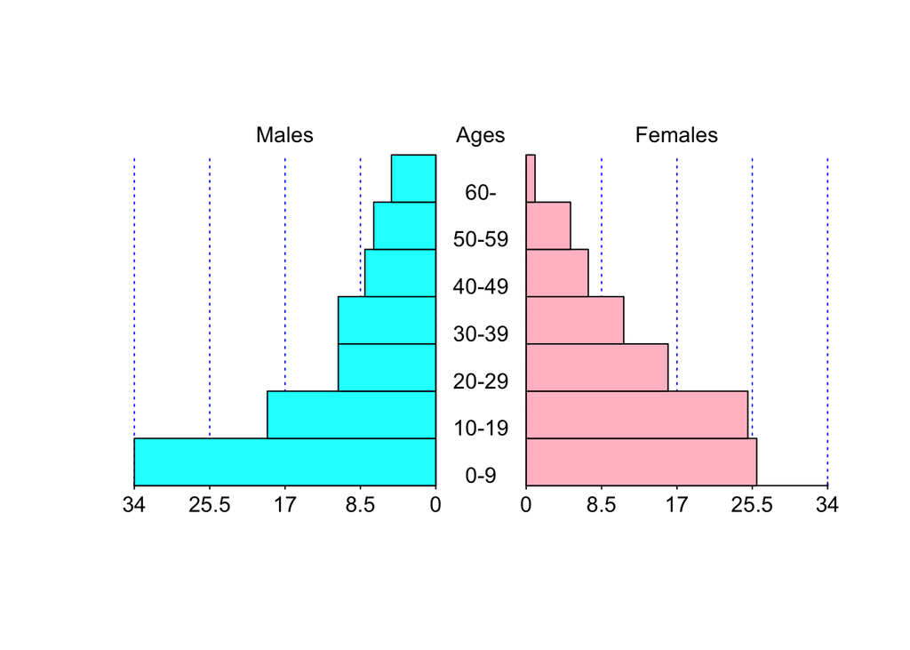

```r
pyramid(data.frame(c(34, 19, 11, 11, 8, 7, 5),
                   c(26, 25, 16, 11, 7, 5, 1),
                   c('0-9', '10-19', '20-29', '30-39', '40-49', '50-59', '60-')))
```

### Ejercicio 3.4

Utilizando los datos del padrón publicado en 2017 relativos a toda España realizar la pirámide de población de España utilizando la función `pyramid()`.

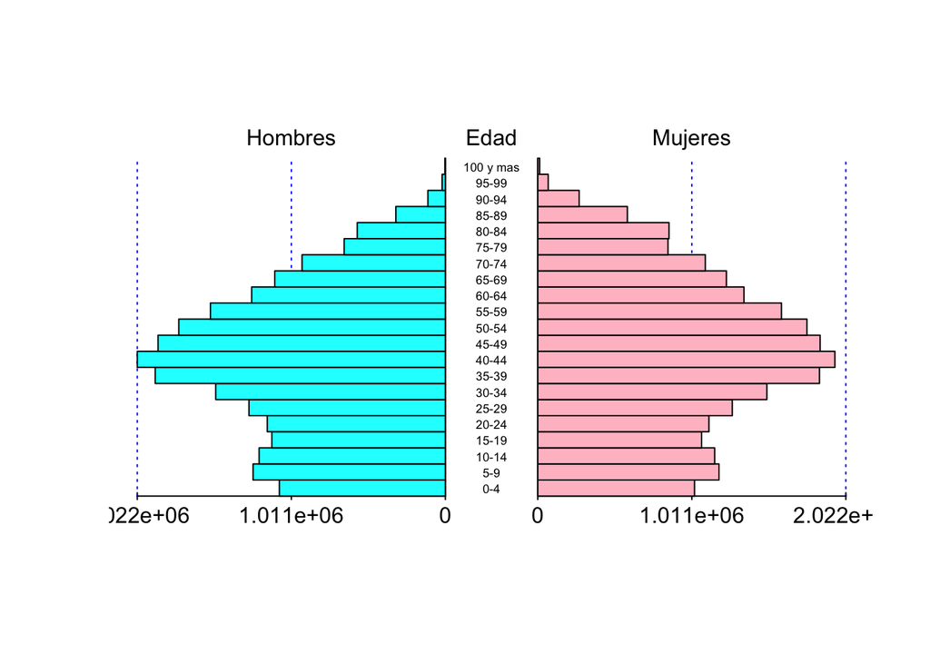

```r
pyramid(data.frame(as.numeric(country[country$sexo == "Hombres", age.range]),
                   as.numeric(country[country$sexo == "Mujeres", age.range]),
                   age.range),
        Csize = 0.55, Clab = "Edad", Llab = "Hombres", Rlab = "Mujeres",
        Laxis = seq(0, max(as.numeric(country[country$sexo == "Hombres", age.range]),
                           as.numeric(country[country$sexo == "Mujeres", age.range])),
                    len = 3))
```

### Ejercicio 3.5

Representar un gráfico con los datos de población de España frente a la edad (marcas de clase) para cada sexo. Realizar una figura similar para todas las comunidades autónomas indicando a cual se refiere de manera adecuada. Seguidamente, grabar todas las figuras en el archivo *“figuras-poblacion-examen.pdf”*.

```r
a <- tidyr::gather(country[, c("sexo", age.range)],
                   key = "Edad", value = "Población", age.range)
a$Edad <- as.numeric(gsub("^([0-9]+).*","\\1", a$Edad))
```

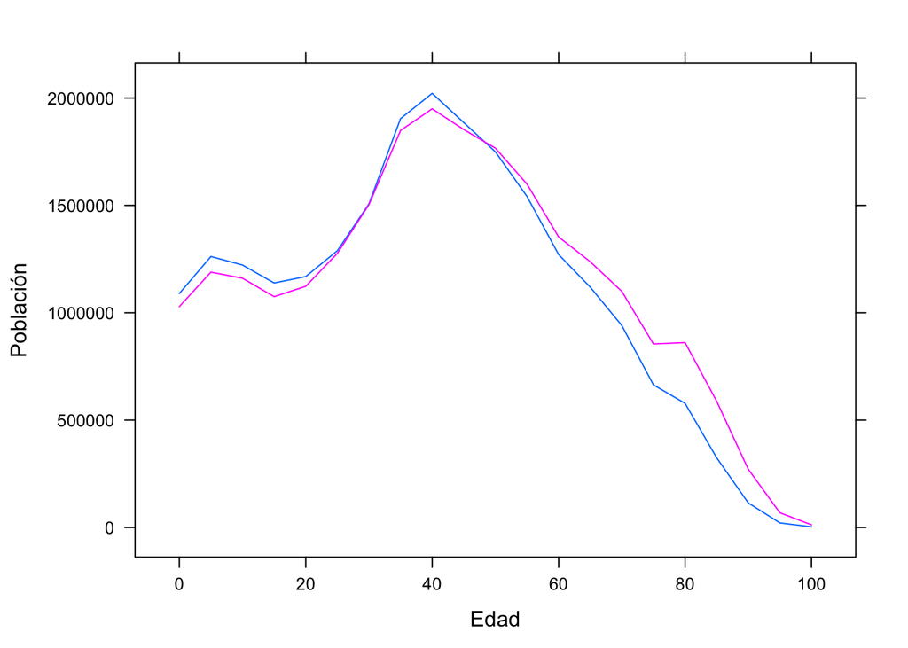

```r
(p <- xyplot(Población ~ Edad, groups = sexo,
             data = a,
             type = "l"))
```

```r
a <- tidyr::gather(ccaa[, c("Region", "sexo", age.range)],
                   key = "Edad", value = "Población", age.range)

a$Edad <- as.numeric(gsub("^([0-9]+).*","\\1", a$Edad))
```

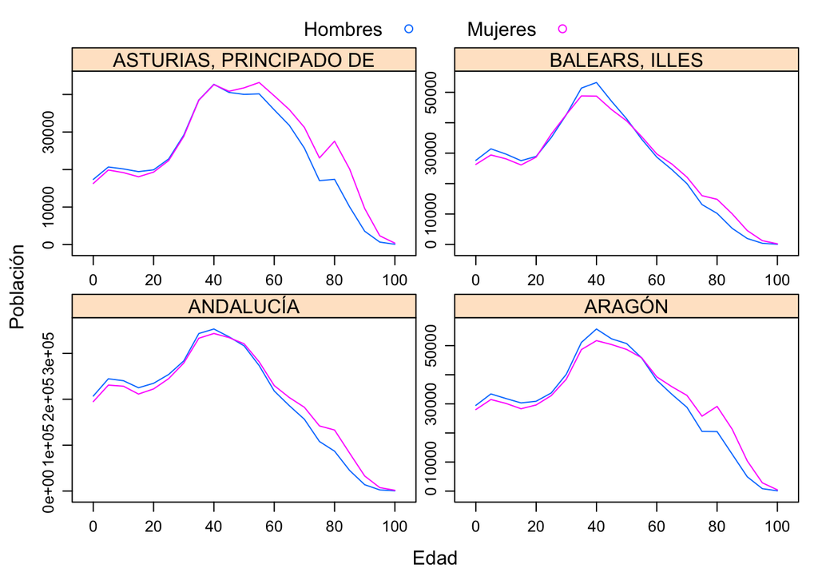

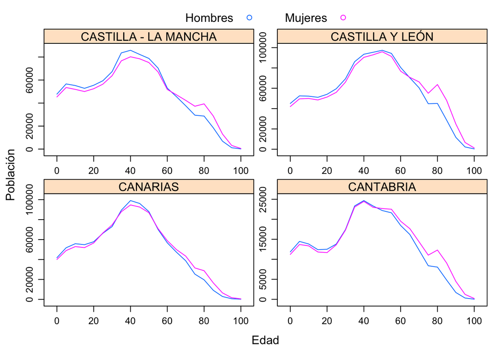

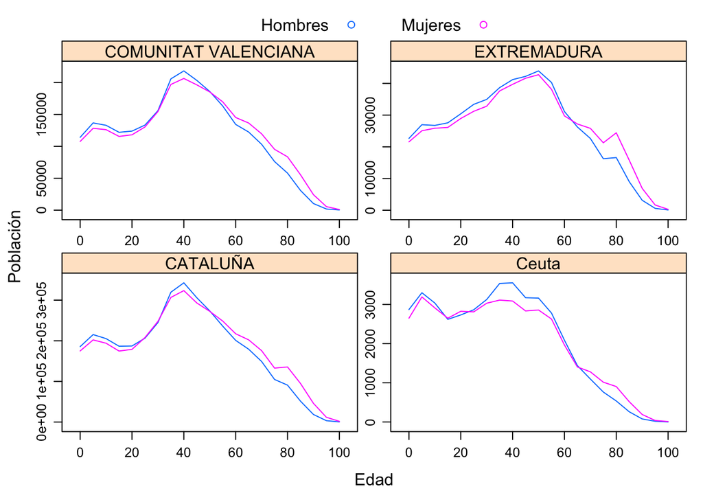

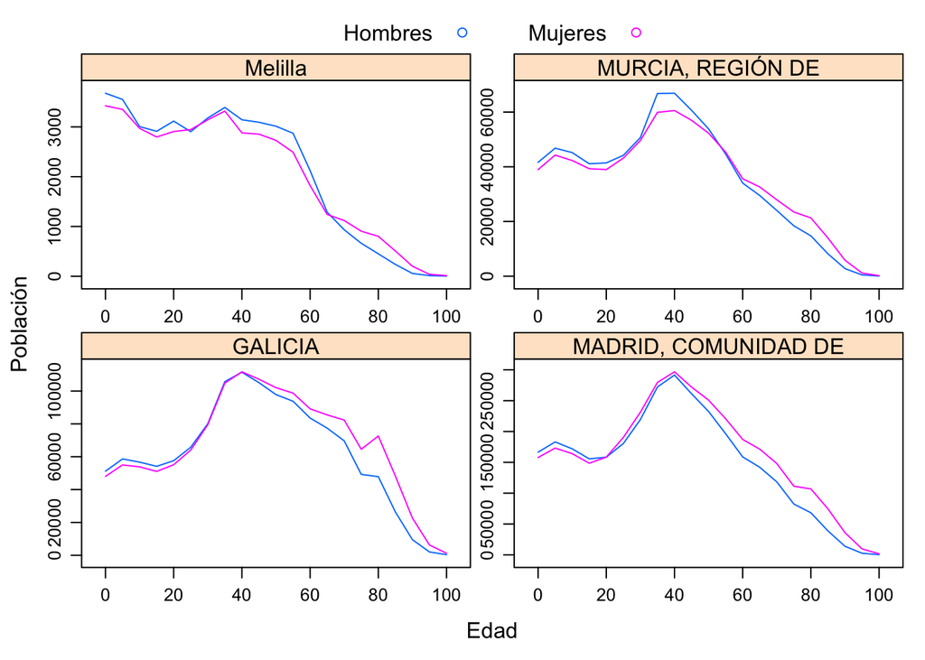

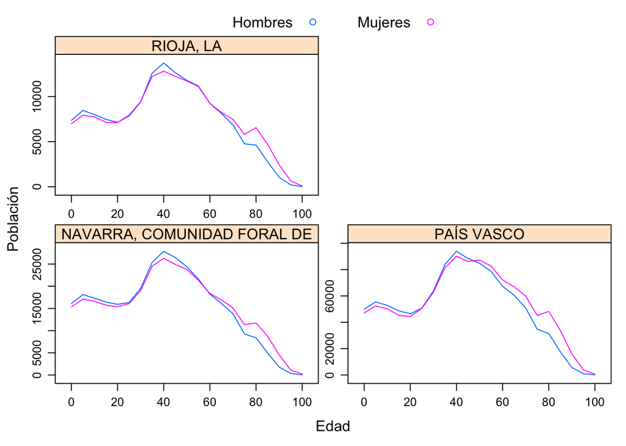

```r
(p <- xyplot(Población ~ Edad | Region, groups = sexo, data = a, type = "l",
       layout = c(2, 2), auto.key = list(points = T, columns = 2),
       scales=list(relation="free")))
```

```r
pdf(file = "figuras-poblacion-examen.pdf")
p
dev.off()
```

### Ejercicio 3.6

Realizar un mapa de España donde la intensidad de los colores de las comunidades autónomas estén determinados en función de la población. Utilizar una paleta de $4$ colores rojizos. Guardar el mapa en un archivo externo.

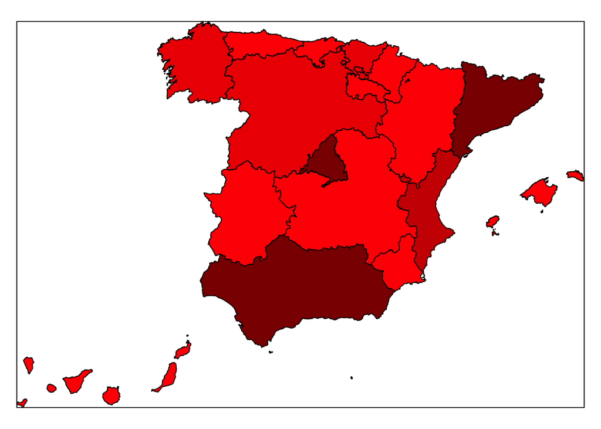

```r
mapSHP <-
  readShapePoly(
    fn = paste0(path, 'mapas_completo_municipal/spain_regions_ind')
  )
ccaa.total <- sapply(unique(ccaa$Region), function(x) {
  sum(ccaa[ccaa$Region == x, age.range])
})
ccaa.total.intervals <- seq(min(ccaa.total),
                            max(ccaa.total), length = 5)

poblacion <- sapply(mapSHP$COM, function(x) {
    i <- match(x, sprintf("CA%02d", ccaa$codigo.ccaa))
    if (is.na(i) | ccaa.total[i] < ccaa.total.intervals[2]) {
      "red1"
    } else if (ccaa.total[i] < ccaa.total.intervals[3]) {
      "red2"
    } else if (ccaa.total[i] < ccaa.total.intervals[4]) {
      "red3"
    } else {
      "red4"
    }
})

mapSHP@data <- cbind(poblacion, mapSHP@data)
spplot(mapSHP["poblacion"], col.regions = paste0("red", 1:4),
       colorkey = FALSE, auto.key = FALSE)
```

### Ejercicio 3.7

Realizar un mapa de España donde la intensidad de los colores de las comunidades autónomas estén determinados en función de la población menor que $20$ años. Utilizar una paleta de $4$ colores azulados. Guardar el mapa en un archivo externo.

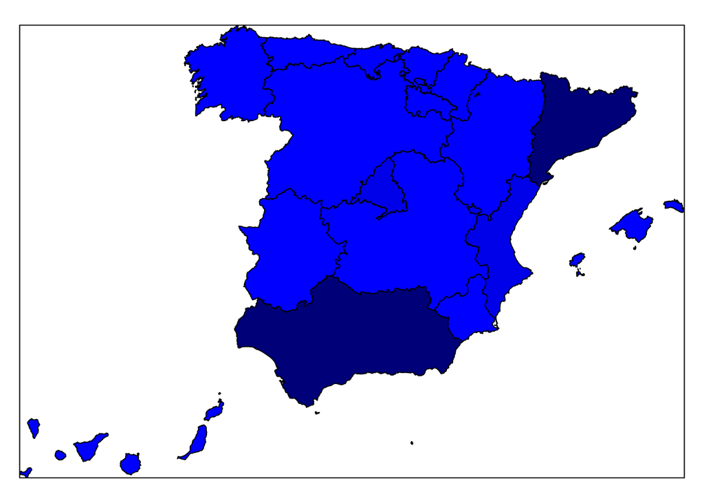

```r
ccaa.total.less.20 <- sapply(unique(ccaa$Region), function(x) {
  sum(ccaa[ccaa$Region == x, age.range.less.20])
})
ccaa.total.intervals.less.20 <- seq(min(ccaa.total.less.20),
                                    max(ccaa.total.less.20), length = 5)
poblacion.less <- sapply(mapSHP$COM, function(x) {
    i <- match(x, sprintf("CA%02d", ccaa$codigo.ccaa))
    if (is.na(i) | ccaa.total.less.20[i] < ccaa.total.intervals.less.20[2]) {
      "blue1"
    } else if (ccaa.total.less.20[i] < ccaa.total.intervals.less.20[3]) {
      "blue2"
    } else if (ccaa.total.less.20[i] < ccaa.total.intervals.less.20[4]) {
      "blue3"
    } else {
      "blue4"
    }
})

mapSHP@data <- cbind(poblacion.less, mapSHP@data)
spplot(mapSHP["poblacion.less"], col.regions = paste0("blue", 1:4),
       colorkey = FALSE, auto.key = FALSE)
```